# Building Drinking Water Viral Set and Visualization

```r
viruses_long_scores <- viruses %>%
  select(contains("keep_score_all_tv")) %>%
  pivot_longer(cols=contains("keep_score_"),
               names_to="rule_combination",
               values_to="viral_score") %>%
  mutate(viral_score=as.factor(round(viral_score))) %>%
  group_by(rule_combination, viral_score) %>%
  summarise(n = n())
```

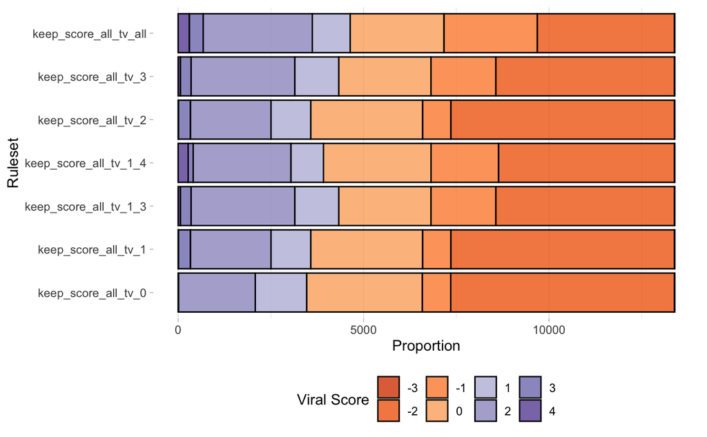

```r
fig <- ggplot(viruses_long_scores, aes(y=n, x=rule_combination,
                   fill=viral_score)) +
  geom_bar(stat="identity", color="black") +
  theme_light() +
  coord_flip() +
  theme(
    panel.grid.major.y = element_blank(),
    panel.border = element_blank(),
    legend.position = "bottom",
    strip.background = element_rect(fill="white", color="grey"),
    strip.text = element_text(color="black")
  ) +
  scale_fill_manual(name="Viral Score",
                     values = alpha(c(rev(RColorBrewer::brewer.pal(9,"Oranges")[4:7]),
                            RColorBrewer::brewer.pal(9,"Purples")[4:9]
                            ), 0.8)) +
  xlab("Ruleset") +
  ylab("Proportion")

fig
```

same idea but VS2 base

```r
viruses$keep_score_vs2_tv_all <- getting_viral_set_1(viruses, include_deepvirfinder = F,
                                              include_vibrant = F,
                                              include_virsorter2 = T,
                                              include_tuning_viral = T,
                                              include_tuning_not_viral = F,
                                              include_virsorter = F)

viruses$keep_score_vs2_tv_4_tv_2 <- getting_viral_set_1(viruses, include_deepvirfinder = F,
                                              include_vibrant = F,
                                              include_virsorter2 = T,
                                              include_tuning_viral = T,
                                              tv_1=F, tv_2=T, tv_3=F, tv_4=T,
                                              include_tuning_not_viral = F,
                                              include_virsorter = F)

viruses$keep_score_vs2_tv_4_tv_2_tv_1 <- getting_viral_set_1(viruses, include_deepvirfinder = F,
                                              include_vibrant = F,
                                              include_virsorter2 = T,
                                              include_tuning_viral = T,
                                              tv_1=T, tv_2=T, tv_3=F, tv_4=T,
                                              include_tuning_not_viral = F,
                                              include_virsorter = F)

viruses$keep_score_vs2_tv_1 <- getting_viral_set_1(viruses, include_deepvirfinder = F,
                                              include_vibrant = F,
                                              include_virsorter2 = T,
                                              include_tuning_viral = T,
                                              tv_1=T, tv_2=F, tv_3=F, tv_4=F,
                                              include_tuning_not_viral = F,
                                              include_virsorter = F)

viruses$keep_score_vs2_tv_2 <- getting_viral_set_1(viruses, include_deepvirfinder = F,
                                              include_vibrant = F,
                                              include_virsorter2 = T,
                                              include_tuning_viral = T,
                                              tv_1=F, tv_2=T, tv_3=F, tv_4=F,
                                              include_tuning_not_viral = F,
                                              include_virsorter = F)

viruses$keep_score_vs2_tv_3 <- getting_viral_set_1(viruses, include_deepvirfinder = F,
                                              include_vibrant = F,
                                              include_virsorter2 = T,
                                              include_tuning_viral = T,
                                              tv_1=F, tv_2=F, tv_3=T, tv_4=F,
                                              include_tuning_not_viral = F,
                                              include_virsorter = F)

viruses$keep_score_vs2_tv_4 <- getting_viral_set_1(viruses, include_deepvirfinder = F,
                                              include_vibrant = F,
                                              include_virsorter2 = T,
                                              include_tuning_viral = T,
                                              tv_1=F, tv_2=F, tv_3=F, tv_4=T,
                                              include_tuning_not_viral = F,
                                              include_virsorter = F)

viruses$keep_score_vs2_tv_0 <- getting_viral_set_1(viruses, include_deepvirfinder = F,
                                              include_vibrant = F,
                                              include_virsorter2 = T,
                                              include_tuning_viral = F,
                                              include_tuning_not_viral = F,
                                              include_virsorter = F)

 viruses$keep_score_vs2_tv_ntv <- getting_viral_set_1(viruses, include_deepvirfinder = F,
                                              include_vibrant = F,
                                              include_virsorter2 = T,
                                              include_tuning_viral = T,
                                              include_tuning_not_viral = T,
                                              include_virsorter = F)

viruses$true_virus <- "not"
viruses$true_virus[viruses$seqtype=="virus"] <- "virus"
```

```
Unknown or uninitialised column: `seqtype`.
```

```r
viruses_long_scores <- viruses %>%
  select(contains("keep_score_vs2_tv_")) %>%
  pivot_longer(cols=contains("keep_score_"),
               names_to="rule_combination",
               values_to="viral_score") %>%
  mutate(viral_score=as.factor(round(viral_score))) %>%
  group_by(rule_combination, viral_score) %>%
  summarise(n = n())
```

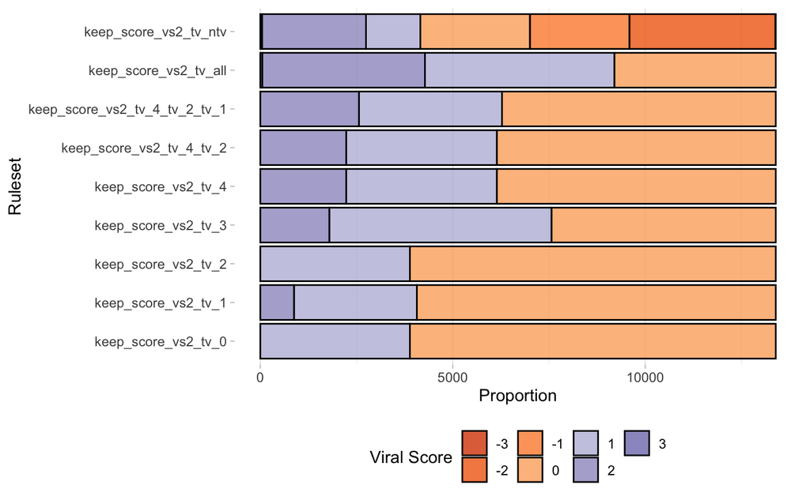

```r
fig <- ggplot(viruses_long_scores, aes(y=n, x=rule_combination,
                   fill=viral_score)) +
  geom_bar(stat="identity", color="black") +
  theme_light() +
  coord_flip() +
  theme(
    panel.grid.major.y = element_blank(),
    panel.border = element_blank(),
    legend.position = "bottom",
    strip.background = element_rect(fill="white", color="grey"),
    strip.text = element_text(color="black")
  ) +
  scale_fill_manual(name="Viral Score",
                     values = alpha(c(rev(RColorBrewer::brewer.pal(9,"Oranges")[4:7]),
                            RColorBrewer::brewer.pal(9,"Purples")[4:9]
                            ), 0.8)) +
  xlab("Ruleset") +
  ylab("Proportion")

fig
```

### Effect of tuning removal rules

```r
viruses$keep_score_all_ntv_all <- getting_viral_set_1(viruses, include_deepvirfinder = T,
                                              include_vibrant = T,
                                              include_virsorter2 = T,
                                              include_tuning_viral = T,
                                              include_tuning_not_viral = T,
                                              include_virsorter = T)

viruses$keep_score_all_ntv_1 <- getting_viral_set_1(viruses, include_deepvirfinder = T,
                                              include_vibrant = T,
                                              include_virsorter2 = T,
                                              include_tuning_viral = T,
                                              ntv_1=T, ntv_2=F, ntv_3=F, ntv_4=F, ntv_5=F,
                                              include_tuning_not_viral = T,
                                              include_virsorter = T)

viruses$keep_score_all_ntv_2 <- getting_viral_set_1(viruses, include_deepvirfinder = T,
                                              include_vibrant = T,
                                              include_virsorter2 = T,
                                              include_tuning_viral = T,
                                              ntv_1=T, ntv_2=T, ntv_3=F, ntv_4=F, ntv_5=F,
                                              include_tuning_not_viral = T,
                                              include_virsorter = T)

viruses$keep_score_all_ntv_3 <- getting_viral_set_1(viruses, include_deepvirfinder = T,
                                              include_vibrant = T,
                                              include_virsorter2 = T,
                                              include_tuning_viral = T,
                                              ntv_1=T, ntv_2=T, ntv_3=T, ntv_4=F, ntv_5=F,
                                              include_tuning_not_viral = T,
                                              include_virsorter = T)

viruses$keep_score_all_ntv_4 <- getting_viral_set_1(viruses, include_deepvirfinder = T,
                                              include_vibrant = T,
                                              include_virsorter2 = T,
                                              include_tuning_viral = T,
                                              ntv_1=T, ntv_2=T, ntv_3=T, ntv_4=T, ntv_5=F,
                                              include_tuning_not_viral = T,
                                              include_virsorter = T)

viruses$keep_score_all_ntv_5 <- getting_viral_set_1(viruses, include_deepvirfinder = T,
                                              include_vibrant = T,
                                              include_virsorter2 = T,
                                              include_tuning_viral = T,
                                              ntv_1=T, ntv_2=T, ntv_3=T, ntv_4=T, ntv_5=T,
                                              include_tuning_not_viral = T,
                                              include_virsorter = T)

viruses$keep_score_all_ntv_0 <- getting_viral_set_1(viruses, include_deepvirfinder = T,
                                              include_vibrant = T,
                                              include_virsorter2 = T,
                                              include_tuning_viral = T,
                                              ntv_1=F, ntv_2=F, ntv_3=F, ntv_4=F, ntv_5=F,
                                              include_tuning_not_viral = F,
                                              include_virsorter = T)

viruses$true_virus <- "not"
viruses$true_virus[viruses$seqtype=="virus"] <- "virus"
```

```
Unknown or uninitialised column: `seqtype`.
```

```r
viruses_long_scores <- viruses %>%
  select(contains("keep_score_all_ntv")) %>%
  pivot_longer(cols=contains("keep_score_"),
               names_to="rule_combination",
               values_to="viral_score") %>%
  mutate(viral_score=as.factor(round(viral_score))) %>%
  group_by(rule_combination, viral_score) %>%
  summarise(n = n())
```

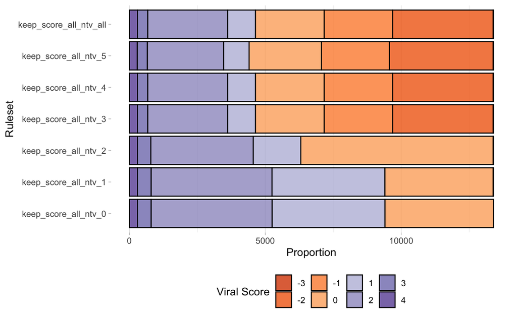

### Effect of tuning removal rules -VS2

```r
viruses$keep_score_vs2_ntv_all <- getting_viral_set_1(viruses, include_deepvirfinder = F,
                                              include_vibrant = F,
                                              include_virsorter2 = T,
                                              include_tuning_viral = F,
                                              include_tuning_not_viral = T,
                                              include_virsorter = F)

viruses$keep_score_vs2_ntv_1 <- getting_viral_set_1(viruses, include_deepvirfinder = F,
                                              include_vibrant = F,
                                              include_virsorter2 = T,
                                              include_tuning_viral = F,
                                              ntv_1=T, ntv_2=F, ntv_3=F, ntv_4=F, ntv_5=F,
                                              include_tuning_not_viral = T,
                                              include_virsorter = F)

viruses$keep_score_vs2_ntv_2 <- getting_viral_set_1(viruses, include_deepvirfinder = F,
                                              include_vibrant = F,
                                              include_virsorter2 = T,
                                              include_tuning_viral = F,
                                              ntv_1=T, ntv_2=T, ntv_3=F, ntv_4=F, ntv_5=F,
                                              include_tuning_not_viral = T,
                                              include_virsorter = F)

viruses$keep_score_vs2_ntv_3 <- getting_viral_set_1(viruses, include_deepvirfinder = F,
                                              include_vibrant = F,
                                              include_virsorter2 = T,
                                              include_tuning_viral = F,
                                              ntv_1=T, ntv_2=T, ntv_3=T, ntv_4=F, ntv_5=F,
                                              include_tuning_not_viral = T,
                                              include_virsorter = F)

viruses$keep_score_vs2_ntv_4 <- getting_viral_set_1(viruses, include_deepvirfinder = F,
                                              include_vibrant = F,
                                              include_virsorter2 = T,
                                              include_tuning_viral = F,
                                              ntv_1=T, ntv_2=T, ntv_3=T, ntv_4=T, ntv_5=F,
                                              include_tuning_not_viral = T,
                                              include_virsorter = F)

viruses$keep_score_vs2_ntv_5 <- getting_viral_set_1(viruses, include_deepvirfinder = F,
                                              include_vibrant = F,
                                              include_virsorter2 = T,
                                              include_tuning_viral = F,
                                              ntv_1=T, ntv_2=T, ntv_3=T, ntv_4=T, ntv_5=T,
                                              include_tuning_not_viral = T,
                                              include_virsorter = F)

viruses$keep_score_vs2_ntv_0 <- getting_viral_set_1(viruses, include_deepvirfinder = F,
                                              include_vibrant = F,
                                              include_virsorter2 = T,
                                              include_tuning_viral = F,
                                              ntv_1=F, ntv_2=F, ntv_3=F, ntv_4=F, ntv_5=F,
                                              include_tuning_not_viral = F,
                                              include_virsorter = F)

viruses$true_virus <- "not"
viruses$true_virus[viruses$seqtype=="virus"] <- "virus"
```

```
Unknown or uninitialised column: `seqtype`.
```

```r
viruses_long_scores <- viruses %>%
  select(contains("keep_score_vs2_ntv")) %>%
  pivot_longer(cols=contains("keep_score_"),
               names_to="rule_combination",
               values_to="viral_score") %>%
  mutate(viral_score=as.factor(round(viral_score))) %>%
  group_by(rule_combination, viral_score) %>%
  summarise(n = n())
```

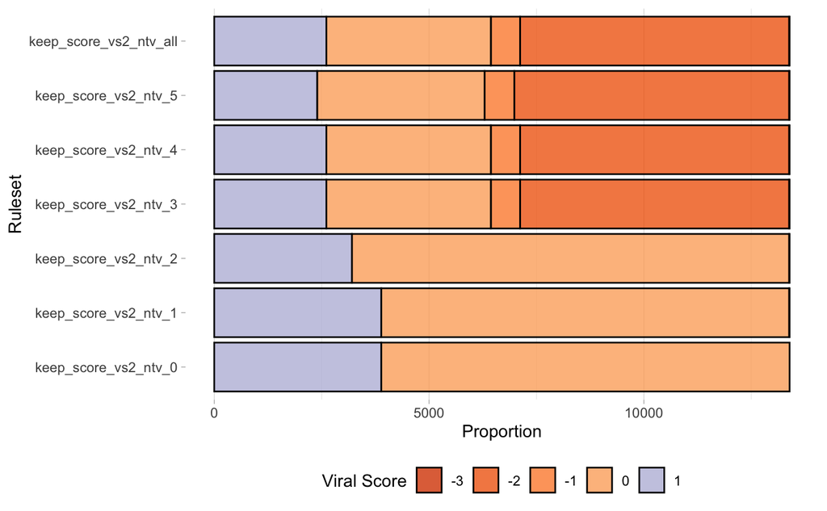

```r
viruses$keep_score_all <- getting_viral_set_1(viruses, include_deepvirfinder = T,
                                              include_vibrant = T,
                                              include_virsorter2 = T,
                                              include_tuning_viral = T,
                                              include_tuning_not_viral = T,
                                              include_virsorter = T)

viruses$keep_score_high_recall <- getting_viral_set_1(viruses, include_deepvirfinder = T,
                                              include_vibrant = T,
                                              include_virsorter2 = T,
                                              include_tuning_viral = T,
                                              include_tuning_not_viral = F,
                                              include_virsorter = T)

viruses$keep_score_high_MCC <- getting_viral_set_1(viruses, include_deepvirfinder = F,
                                              include_vibrant = T,
                                              include_virsorter2 = T,
                                              include_tuning_viral = T,
                                              include_tuning_not_viral = T,
                                              include_virsorter = T)

viruses$keep_score_high_precision <- getting_viral_set_1(viruses, include_deepvirfinder = T,
                                              include_vibrant = T,
                                              include_virsorter2 = F,
                                              include_tuning_viral = F,
                                              include_tuning_not_viral = T,
                                              include_virsorter = F)
```

```r
sum(viruses$keep_score_all>=1)
```

```
[1] 4638
```

```r
sum(viruses$keep_score_high_recall>=1)
```

```
[1] 9401
```

```r
sum(viruses$keep_score_high_precision>=1)
```

```
[1] 1744
```

```r
sum(viruses$keep_score_high_MCC>=1)
```

```
[1] 4192
```

```r
sum(viruses$keep_score_all>=0.5)
```

```
[1] 5454
```

```r
sum(viruses$keep_score_high_recall>=0.5)
```

```
[1] 13391
```

```r
sum(viruses$keep_score_high_precision>=0.5)
```

```
[1] 2310
```

```r
sum(viruses$keep_score_high_MCC>=0.5)
```

```
[1] 5184
```

```r
write_csv(viruses[,c(1,43:46)], "drinking_water_top_viral_scores.csv")
```

not having the rule, gives the same

Create list of contigs considered viral

```r
#c_list <- data.frame(viruses_high$checkv_uniq_contig)
#write_tsv(c_list, paste(dataset_name, "viruses_high_uniq_contig_list.tsv", sep='_'))
```

Export keep_score_high and list of contigs considered viral by the combined tool.

```r
#write_tsv(viruses_high, paste(dataset_name, "viruses_high.tsv", sep='_'))
```

# Comparing all of the tool methods

```r
combos_list <- data.frame(toolcombo=rep(0, 64),
                          tune_not_viral=rep(0, 64),
                          DVF=rep(0, 64),
                          tune_viral=rep(0, 64),
                          VIBRANT=rep(0, 64),
                          VS=rep(0, 64),
                          VS2=rep(0, 64))
p <- 1

for (i in c(0,1)){
  for (j in c(0,1)){
    for (k in c(0,1)){
      for (l in c(0,1)){
        for (m in c(0,1)){
          for (n in c(0,1)){
            combos_list$toolcombo[p] <- paste(i,j,k,l,m,n)
            combos_list$toolcombo2[p] <- paste(if(i){"tnv"}else{"0"},if(j){"DVF"}else{"0"},
                                               if(k){"tv"}else{"0"},if(l){"VB"}else{"0"},
                                               if(m){"VS"}else{"0"},if(n){"VS2"}else{"0"})
            combos_list$tune_not_viral[p] <- i
            combos_list$DVF[p] <- j
            combos_list$tune_viral[p] <- k
            combos_list$VIBRANT[p] <- l
            combos_list$VS[p] <- m
            combos_list$VS2[p] <- n
            p <- p+1
          }
        }
      }
    }
  }
}

combos_list <- combos_list[-1,]
```

```r
viral_scores <- matrix(data=0, nrow=nrow(viruses), ncol=nrow(combos_list))
num_viruses <- data.frame(toolcombo=rep(0, nrow(combos_list)),
                          num_viruses=rep(0, nrow(combos_list)))
for (i in 1:nrow(combos_list)) {
  viral_scores[,i] <- getting_viral_set_1(viruses, include_vibrant = combos_list$VIBRANT[i],
                                            include_virsorter = combos_list$VS[i],
                                            include_virsorter2 = combos_list$VS2[i],
                                            include_tuning_viral = combos_list$tune_viral[i],
                                            include_tuning_not_viral = combos_list$tune_not_viral[i],
                                            include_deepvirfinder = combos_list$DVF[i])

  if (max(viral_scores[,i])<=0) {
    num_viruses$num_viruses[i] <- 0
  }
  else {
    num_viruses$num_viruses[i] <- table(viral_scores[,i]>=1)[[2]]
  }
  num_viruses$toolcombo[i] <- combos_list$toolcombo[i]

  num_viruses$toolcombo2[i] <- combos_list$toolcombo2[i]
}
num_viruses$numtools <- stringr::str_count(num_viruses$toolcombo, "1")
num_viruses <- num_viruses[order(num_viruses$num_viruses, decreasing=F),]
num_viruses$toolcombo <- factor(num_viruses$toolcombo, levels = unique(num_viruses$toolcombo))
num_viruses$toolcombo2 <- factor(num_viruses$toolcombo2, levels = unique(num_viruses$toolcombo2))
num_viruses$numtools <- as.factor(num_viruses$numtools)
```

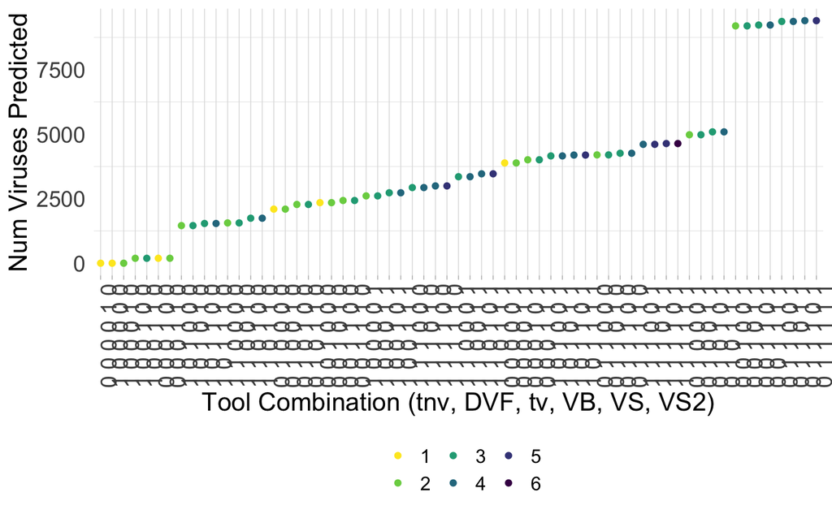

```r
viral_scores <- matrix(data=0, nrow=nrow(viruses), ncol=nrow(combos_list))

num_assemblies <- dim(table(viruses$assembly))
assemblies <- names(table(viruses$assembly))

num_viruses <- data.frame(toolcombo=rep(0, nrow(combos_list)*num_assemblies),
                          toolcombo2=rep(0, nrow(combos_list)*num_assemblies),
                          assembly=rep(0,nrow(combos_list)*num_assemblies),
                          num_viruses=rep(0, nrow(combos_list)*num_assemblies),
                          prop_vir=rep(0, nrow(combos_list)*num_assemblies)
                          )

n <- 1
for (i in 1:nrow(combos_list)) {
  viral_scores[,i] <- getting_viral_set_1(viruses, include_vibrant = combos_list$VIBRANT[i],
                                            include_virsorter = combos_list$VS[i],
                                            include_virsorter2 = combos_list$VS2[i],
                                            include_tuning_viral = combos_list$tune_viral[i],
                                            include_tuning_not_viral = combos_list$tune_not_viral[i],
                                            include_deepvirfinder = combos_list$DVF[i])
  for (j in 1:num_assemblies) {
    if (max(viral_scores[,i])<=0) {
      num_viruses$num_viruses[n] <- 0
    }
    else {
      num_viruses$num_viruses[n] <- sum(viral_scores[viruses$assembly==assemblies[j],i]>=1)
      num_viruses$prop_vir[n] <- num_viruses$num_viruses[n]/table(viruses$assembly)[[j]]
    }

    num_viruses$toolcombo[n] <- combos_list$toolcombo[i]
    num_viruses$toolcombo2[n] <- combos_list$toolcombo2[i]
    num_viruses$assembly[n] <- assemblies[j]

    n <- n+1
  }
}

num_viruses$numtools <- stringr::str_count(num_viruses$toolcombo, "1")
num_viruses <- num_viruses[order(num_viruses$prop_vir, decreasing=F),]
num_viruses$toolcombo <- factor(num_viruses$toolcombo, levels = unique(num_viruses$toolcombo))
num_viruses$toolcombo2 <- factor(num_viruses$toolcombo2, levels = unique(num_viruses$toolcombo2))
num_viruses$numtools <- as.factor(num_viruses$numtools)
```

```r
write_csv(num_viruses, "drinking_water_num_viruses.csv")
```

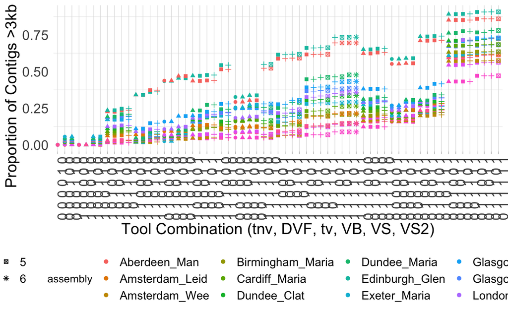

```r
ggplot(num_viruses, aes(x=toolcombo, y=prop_vir,
                                  shape=numtools, color=assembly, fill=assembly)) +
  geom_point() +
  theme_light() +
  theme(
    panel.grid.major.y = element_blank(),
    panel.border = element_blank(),
    axis.ticks.y = element_blank(),
    legend.position = "bottom",
    axis.text.y=element_text(size=14),
    axis.text.x=element_text(size=14, angle = 90),
    legend.text=element_text(size=12),
    axis.title=element_text(size=16),
  ) +
  xlab("Tool Combination (tnv, DVF, tv, VB, VS, VS2)") +
  ylab("Proportion of Contigs >3kb Viral")
```

```r
num_viruses$numtools <- as.numeric(num_viruses$numtools)

median_prop_vir_by_tool <- num_viruses %>%
  select(toolcombo, prop_vir, numtools) %>%
  group_by(toolcombo) %>%
  summarize(median=median(prop_vir),
         #sd=sd(prop_vir),
         numtools=mean(numtools))

median_prop_vir_by_tool$toolcombo <- factor(median_prop_vir_by_tool$toolcombo,
                                          levels = median_prop_vir_by_tool$toolcombo[order(median_prop_vir_by_tool$median, decreasing = F)])

median_prop_vir_by_tool$numtools <- as.factor(median_prop_vir_by_tool$numtools)
```

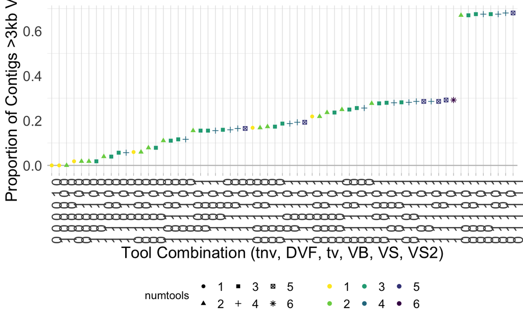

```r
ggplot(median_prop_vir_by_tool, aes(y=median, x=toolcombo,
                                  color=numtools, fill=numtools, shape=numtools))  +
  geom_hline(yintercept=0, color="grey") +
  geom_point() +
#  geom_errorbar(aes(ymin=mean-sd, ymax=mean+sd), width=.2,
#                 position=position_dodge(.9)) +
  theme_light() +
  theme(
    panel.grid.major.y = element_blank(),
    panel.border = element_blank(),
    axis.ticks.y = element_blank(),
    legend.position = "bottom",
    axis.text.y=element_text(size=14),
    axis.text.x=element_text(size=14, angle = 90),
    legend.text=element_text(size=12),
    axis.title=element_text(size=16),
  ) +
  xlab("Tool Combination (tnv, DVF, tv, VB, VS, VS2)") +
  ylab("Proportion of Contigs >3kb Viral") +
  scale_fill_manual(name="",
                     values = alpha(rev(viridis(6)), 0.5)) +
  scale_color_manual(name="",
                     values = alpha(rev(viridis(6)), 1))
```

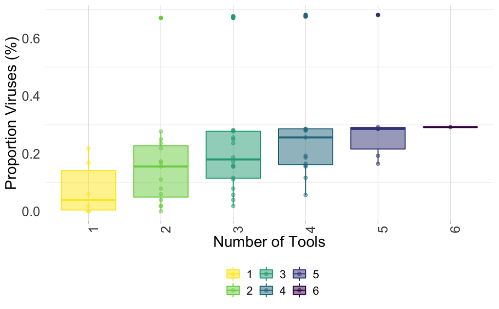

by only a subset of the assemblies (UK/NL)

```r
num_viruses_uknl <- num_viruses[num_viruses$assembly %in% c("Aberdeen_Man",
                                                            "Amsterdam_Leid",
                                                            "Amsterdam_Wee",
                                                            "Birmingham_Maria",
                                                            "Cardiff_Maria",
                                                            "Dundee_Clat",
                                                            "Dundee_Maria",
                                                            "Edinburgh_Glen",
                                                            "Exeter_Maria",
                                                            "Glasgow_Bal",
                                                            "Glasgow_Mil",
                                                            "London_Maria",
                                                            "Nieuwkoop_DHB",
                                                            "South_Holland_Dla",
                                                            "Spannenburg"),]

num_viruses_uknl$residual <- "residual"
num_viruses_uknl$residual[num_viruses_uknl$assembly=="Amsterdam_Leid" |
                          num_viruses_uknl$assembly=="Amsterdam_Wee" |
                          num_viruses_uknl$assembly=="Nieuwkoop_DHB" |
                          num_viruses_uknl$assembly=="South_Holland_Dla" |
                          num_viruses_uknl$assembly=="Spannenburg"
                          ] <- "no residual"
```

```r
num_viruses_uknl$numtools <- as.numeric(num_viruses_uknl$numtools)

mean_prop_vir_by_tool <- num_viruses_uknl %>%
  select(toolcombo, prop_vir, numtools, residual) %>%
  group_by(toolcombo, residual) %>%
  summarize(prop_vir=mean(prop_vir),
         #sd_per_vir=sd(prop_vir),
         numtools=mean(numtools))
mean_uknl <- mean_prop_vir_by_tool %>%
  group_by(toolcombo) %>%
  summarize(mean=mean(prop_vir))

mean_prop_vir_by_tool$toolcombo <- factor(mean_prop_vir_by_tool$toolcombo,
                                          levels = mean_uknl$toolcombo[order(mean_uknl$mean, decreasing = F)])

mean_prop_vir_by_tool$numtools <- as.factor(mean_prop_vir_by_tool$numtools)
```

```r
num_viruses_uknl$toolcombo <- factor(num_viruses_uknl$toolcombo,
                                          levels = levels(mean_prop_vir_by_tool$toolcombo))
num_viruses_uknl$numtools <- as.factor(num_viruses_uknl$numtools)
```

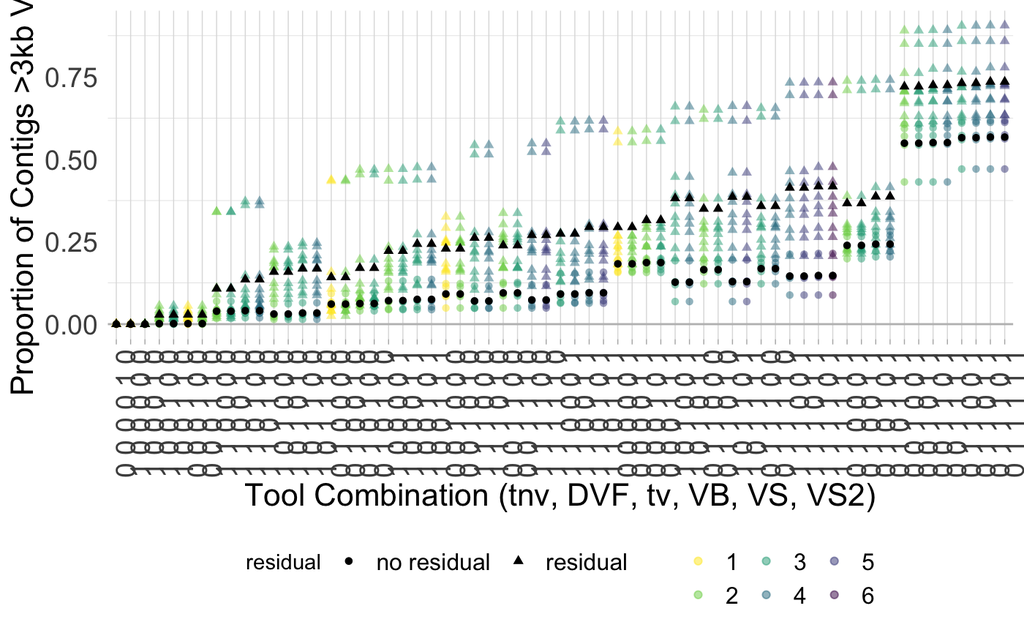

```r
ggplot(num_viruses_uknl) +
  geom_hline(yintercept=0, color="grey") +
  geom_point(aes(color=numtools, fill=numtools, y=prop_vir, x=toolcombo, shape=residual), alpha=0.5) +
  geom_point(data=mean_prop_vir_by_tool, aes(x=toolcombo,
                                               y=prop_vir,
                                             shape=residual),
             color="black") +
  theme_light() +
  theme(
    panel.grid.major.y = element_blank(),
    panel.border = element_blank(),
    axis.ticks.y = element_blank(),
    legend.position = "bottom",
    axis.text.y=element_text(size=14),
    axis.text.x=element_text(size=14, angle = 90),
    legend.text=element_text(size=12),
    axis.title=element_text(size=16),
  ) +
  xlab("Tool Combination (tnv, DVF, tv, VB, VS, VS2)") +
  ylab("Proportion of Contigs >3kb Viral") +
  scale_fill_manual(name="",
                     values = alpha(rev(viridis(6)), 0.5)) +
  scale_color_manual(name="",
                     values = alpha(rev(viridis(6)), 1))
```

```r
t.test(num_viruses_uknl$prop_vir[num_viruses_uknl$residual=="residual"],
       num_viruses_uknl$prop_vir[num_viruses_uknl$residual=="no residual"]
       )
```

```
    Welch Two Sample t-test

data:  num_viruses_uknl$prop_vir[num_viruses_uknl$residual == "residual"] and num_viruses_uknl$prop_vir[num_viruses_uknl$residual == "no residual"]
t = 11.079, df = 824.43, p-value < 2.2e-16
alternative hypothesis: true difference in means is not equal to 0
95 percent confidence interval:
 0.1216574 0.1740461
sample estimates:
mean of x mean of y
0.3034406 0.1555889
```

ordination: sample by tool combo

```r
library(phyloseq)
```

make the sample by tool combo matrix

```r
num_viruses_uknl_wide <- num_viruses_uknl %>%
  select(toolcombo, assembly, num_viruses) %>%
  pivot_wider(names_from=assembly, values_from=num_viruses)
num_viruses_uknl_wide <- as.data.frame(num_viruses_uknl_wide)
rownames(num_viruses_uknl_wide) <- num_viruses_uknl_wide$toolcombo
num_viruses_uknl_wide <- num_viruses_uknl_wide[,-1]

num_viruses_uknl_wide <- num_viruses_uknl_wide[rowSums(num_viruses_uknl_wide)>0,]
```

```r
tooldata <- combos_list
rownames(tooldata) <- tooldata$toolcombo

tooldata <- tooldata[c(rownames(num_viruses_uknl_wide)),]

tooldata$numtools <- str_count(tooldata$toolcombo, "1")

tooldata$numtools <- as.factor(tooldata$numtools)

tooldata$total_viruses <- rowSums(num_viruses_uknl_wide)
```

to reduce arch effect:

```r
num_viruses_uknl_wide <- num_viruses_uknl_wide/rowSums(num_viruses_uknl_wide)
```

```r
physeq_pooled <- phyloseq::phyloseq(phyloseq::otu_table(num_viruses_uknl_wide, taxa_are_rows = F),
                                     phyloseq::sample_data(tooldata))
```

```r
ordination <- phyloseq::ordinate(physeq =physeq_pooled, method = "PCoA", distance = "bray")
```

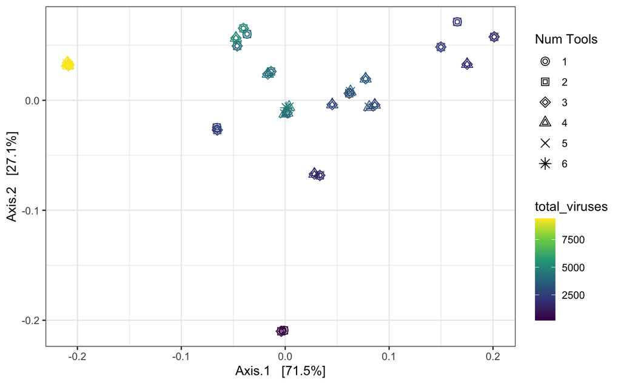

```r
phyloseq::plot_ordination(physeq = physeq_pooled, ordination = ordination,
                          shape="numtools",
                          color="total_viruses") +
  geom_point(size = 3) +
  theme_bw() +
  scale_shape_manual(name="Num Tools",
                     values = c(21,22,23,24,4,8)) +
  scale_color_viridis_c()
```

each point is tool combination

```r
viral_scores_nozeros <- viral_scores[rowSums(viral_scores)>0,]
viral_scores_nozeros <- viral_scores_nozeros + 1
viral_scores_nozeros <- as.data.frame(viral_scores_nozeros)

colnames(viral_scores_nozeros) <- num_viruses$toolcombo2
```

[output not shown]

```r
library(phyloseq)
```

```r
tooldata <- num_viruses

rownames(tooldata) <- tooldata$toolcombo2
```

```r
physeq_pooled <- phyloseq(otu_table(viral_scores_nozeros, taxa_are_rows = T),
                                     sample_data(tooldata))
```

```r
ordination <- phyloseq::ordinate(physeq =physeq_pooled, method = "PCoA", distance = "bray")
phyloseq::plot_ordination(physeq = physeq_pooled, ordination = ordination,
                          shape="numtools", color="num_viruses") +
  geom_point(size = 3) +
  theme_bw() +
  geom_label(label=tooldata$toolcombo)

phyloseq::plot_ordination(physeq = physeq_pooled, ordination = ordination,
                          shape="numtools", color="num_viruses") +
  geom_point(size = 3) +
  theme_bw()
```

to do: try coloring above based on the F1 scores of the testing set on each combination

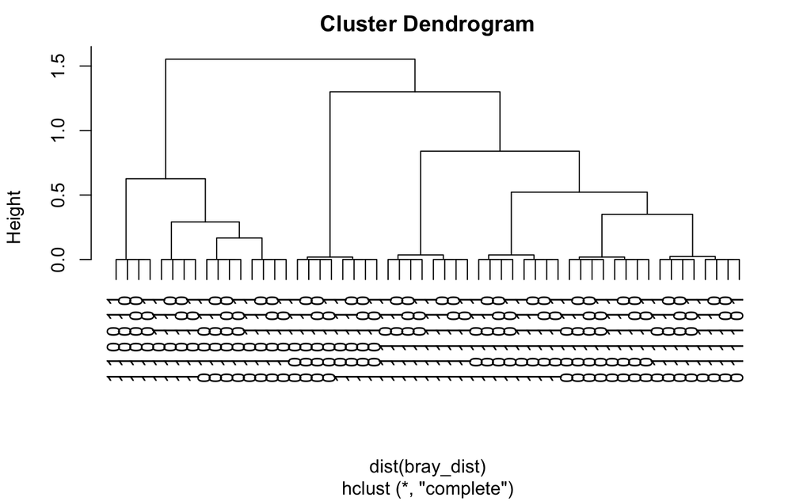

```r
bray_dist <- phyloseq::distance(physeq_pooled, method="bray")
clusters <- hclust(dist(bray_dist))
plot(clusters)
```

```r
myclusters <- cutree(clusters, h=0.8)
```

```r
names(myclusters[myclusters==1])
```

```
[1] "0 0 0 1 0 0" "0 0 0 1 0 1" "0 0 0 1 1 0" "0 0 0 1 1 1" "1 0 0 1 0 0" "1 0 0 1 0 1"
[7] "1 0 0 1 1 0" "1 0 0 1 1 1"
```

```r
names(myclusters[myclusters==2])
```

```
 [1] "1 1 0 0 0 0" "1 1 0 0 0 1" "1 1 0 0 1 0" "1 1 0 0 1 1" "1 1 0 1 0 0" "1 1 0 1 0 1"
 [7] "1 1 0 1 1 0" "1 1 0 1 1 1" "0 1 0 0 0 0" "0 1 0 0 0 1" "0 1 0 0 1 0" "0 1 0 0 1 1"
[13] "0 1 0 1 0 0" "0 1 0 1 0 1" "0 1 0 1 1 0" "0 1 0 1 1 1"
```

```r
names(myclusters[myclusters==3])
```

```
 [1] "1 0 1 0 0 0" "1 0 1 0 0 1" "1 0 1 0 1 0" "1 0 1 0 1 1" "1 0 1 1 0 0" "1 0 1 1 0 1"
 [7] "1 0 1 1 1 0" "1 0 1 1 1 1" "0 0 1 0 0 0" "0 0 1 0 0 1" "0 0 1 0 1 0" "0 0 1 0 1 1"
[13] "0 0 1 1 0 0" "0 0 1 1 0 1" "0 0 1 1 1 0" "0 0 1 1 1 1" "0 1 1 0 0 0" "0 1 1 0 0 1"
[19] "0 1 1 0 1 0" "0 1 1 0 1 1" "0 1 1 1 0 0" "0 1 1 1 0 1" "0 1 1 1 1 0" "0 1 1 1 1 1"
```

```r
names(myclusters[myclusters==4])
```

```
[1] "1 1 1 0 0 0" "1 1 1 0 0 1" "1 1 1 0 1 0" "1 1 1 0 1 1" "1 1 1 1 0 0" "1 1 1 1 0 1"
[7] "1 1 1 1 1 0" "1 1 1 1 1 1"
```

```r
names(myclusters[myclusters==5])
```

```
character(0)
```

```r
myclusters_df <- tibble(combo=names(myclusters),
                            cluster_index=myclusters)

myclusters_df <- separate(myclusters_df, col=combo, into=c("CheckV", "DVF",
                                                            "Kaiju", "VIBRANT",
                                                            "VirSorter", "VirSorter2"),
                          sep=" ", remove = F)


tool_count <- as.data.frame(rbind(table(myclusters_df$CheckV, myclusters_df$cluster_index)[2,],
                          table(myclusters_df$DVF, myclusters_df$cluster_index)[2,],
                          table(myclusters_df$Kaiju, myclusters_df$cluster_index)[2,],
                          table(myclusters_df$VIBRANT, myclusters_df$cluster_index)[2,],
                          table(myclusters_df$VirSorter, myclusters_df$cluster_index)[2,],
                          table(myclusters_df$VirSorter2, myclusters_df$cluster_index)[2,])
                    )

tool_count$method <- c("CheckV", "DVF", "Kaiju", "VIBRANT", "VirSorter", "VirSorter2")

tool_count <- melt(tool_count)
```

[output not shown]

```r
colnames(tool_count) <- c("tool", "cluster_index", "tool_count")
```

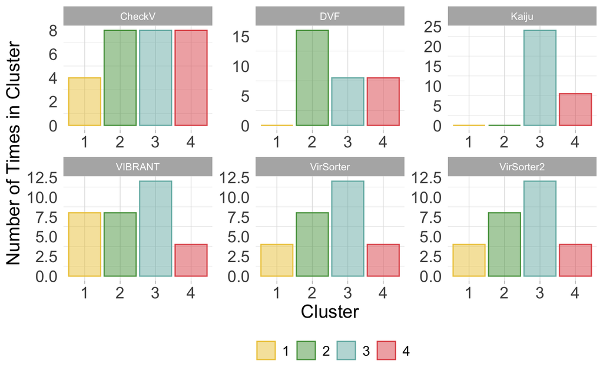

```r
ggplot(tool_count, aes(x=cluster_index, y=tool_count,
                   fill=cluster_index,
                   color=cluster_index)) +
  geom_bar(stat="identity") +
  theme_light() +
  theme(
    panel.grid.major.y = element_blank(),
    panel.border = element_blank(),
    axis.ticks.y = element_blank(),
    legend.position = "bottom",
    axis.text.y=element_text(size=14),
    axis.text.x=element_text(size=14),
    legend.text=element_text(size=12),
    axis.title=element_text(size=16),
  ) +
  scale_fill_manual(name="",
                     values = alpha(rev(pal(6)), 0.5)) +
  scale_color_manual(name="",
                     values = alpha(rev(pal(6)), 1)) +
  xlab("Cluster") +
  ylab("Number of Times in Cluster") +
  facet_wrap(~tool, scales = "free")
```

```r
write_tsv(num_viruses, "dw_num_viruses_by_tool_combo.tsv")
num_viruses <- read_tsv("dw_num_viruses_by_tool_combo.tsv")
```

```r
accuracy_scores <- read_tsv("../../TestingPipeline/Scripts/20220927_accuracy_scores.tsv")
```

```r
num_viruses_comp <- full_join(num_viruses, accuracy_scores[accuracy_scores$testing_set_index==1,], by=c("toolcombo", "numtools"))
```

```r
num_viruses_comp$numtools <- as.factor(num_viruses_comp$numtools)
```

```r
ggplot(num_viruses_comp, aes(x=num_viruses, y=F1,
                                  color=numtools, fill=numtools)) +
  geom_point(alpha=0.5) +
  theme_light() +
  theme(
    panel.grid.major.y = element_blank(),
    panel.border = element_blank(),
    axis.ticks.y = element_blank(),
    legend.position = "bottom",
    axis.text.y=element_text(size=14),
    axis.text.x=element_text(size=14, angle = 90),
    legend.text=element_text(size=12),
    axis.title=element_text(size=16),
  ) +
  ylab("F1") +
  xlab("Num Viruses Predicted")
```

[output not shown]

# Visualizing how tools build on each other

```r
viruses$keep_score_vb <- getting_viral_set_1(viruses, include_deepvirfinder = F,
                                              include_vibrant = T,
                                              include_virsorter2 = F,
                                              include_tuning_viral = F,
                                              include_tuning_not_viral = F,
                                              include_virsorter = F)

viruses$keep_score_vb_dvf <- getting_viral_set_1(viruses, include_deepvirfinder = T,
                                              include_vibrant = T,
                                              include_virsorter2 = F,
                                              include_tuning_viral = F,
                                              include_tuning_not_viral = F,
                                              include_virsorter = F)

viruses$keep_score_vb_dvf_vs2 <- getting_viral_set_1(viruses, include_deepvirfinder = T,
                                              include_vibrant = T,
                                              include_virsorter2 = T,
                                              include_tuning_viral = F,
                                              include_tuning_not_viral = F,
                                              include_virsorter = F)

viruses$keep_score_vb_dvf_vs2_vs <- getting_viral_set_1(viruses, include_deepvirfinder = T,
                                              include_vibrant = T,
                                              include_virsorter2 = T,
                                              include_tuning_viral = F,
                                              include_tuning_not_viral = F,
                                              include_virsorter = T)

viruses$keep_score_vb_dvf_vs2_vs_tv <- getting_viral_set_1(viruses, include_deepvirfinder = T,
                                              include_vibrant = T,
                                              include_virsorter2 = T,
                                              include_tuning_viral = T,
                                              include_tuning_not_viral = F,
                                              include_virsorter = T)

viruses$keep_score_vb_dvf_vs2_vs_tv_tnv <- getting_viral_set_1(viruses, include_deepvirfinder = T,
                                              include_vibrant = T,
                                              include_virsorter2 = T,
                                              include_tuning_viral = T,
                                              include_tuning_not_viral = T,
                                              include_virsorter = T)
```

# Considering how each method contributes to the final prediction

```r
viruses_high <- viruses[viruses$keep_score_vb_dvf_vs2_vs_tv>=1,]
viruses_high_mod <- viruses_high %>% select(keep_score_vb,keep_score_vb_dvf,
                                            keep_score_vb_dvf_vs2, keep_score_vb_dvf_vs2_vs,
                                            keep_score_vb_dvf_vs2_vs_tv, keep_score_vb_dvf_vs2_vs_tv_tnv)
#viruses_high_mod <- apply(viruses_high_mod, c(1,2), function(x) {if (x >= 1) {x <- 1} else {x <- 0}})
viruses_high_mod <- as_tibble(viruses_high_mod)
```

```r
sm_m <- reshape2::melt(viruses_high_mod)
colnames(sm_m) <- c("method", "viral_score")
```

```r
sm_m <- sm_m[sm_m$viral_score>0,]

sm_m$score <- sm_m$viral_score

sm_m$score[sm_m$viral_score==0.5] <- "0.5"
sm_m$score[sm_m$viral_score>=1] <- "1"
sm_m$score[sm_m$viral_score>=2] <- "2"
sm_m$score[sm_m$viral_score>=3] <- "3"
sm_m$score[sm_m$viral_score>=4] <- "4"
sm_m$score[sm_m$viral_score>=5] <- "5"

sm_m$score <- factor(sm_m$score,
                                       levels=c("0.5", "1", "2","3","4","5"))
```

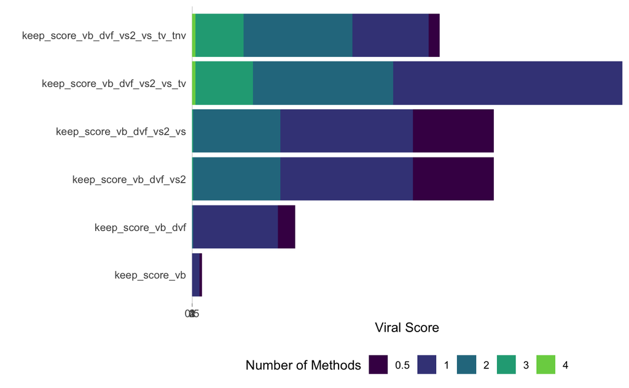

```r
ggplot(sm_m, aes(x=method, y=score,
                   fill=score)) +
  geom_bar(stat="identity") +
  theme_light() +
  coord_flip() +
  theme(
    panel.grid.major.y = element_blank(),
    panel.border = element_blank(),
    axis.ticks.y = element_blank(),
    legend.position = "bottom"
  ) +
  scale_fill_manual(name = 'Number of Methods',
                     values = alpha(c(viridis(6)), 1)) +
  xlab("") +
  ylab("Viral Score") +
  coord_flip()
```

Comparing three recommendations

```r
viruses$keep_score_few_tools <- getting_viral_set_1(viruses, include_deepvirfinder = F,
                                              include_vibrant = F,
                                              include_virsorter2 = T,
                                              include_tuning_viral = T,
                                              include_tuning_not_viral = T,
                                              include_virsorter = F)
```

```r
viruses$keep_score_all <- getting_viral_set_1(viruses, include_deepvirfinder = T,
                                              include_vibrant = T,
                                              include_virsorter2 = T,
                                              include_tuning_viral = T,
                                              include_tuning_not_viral = T,
                                              include_virsorter = T)
```

```r
viruses$keep_score_high_MCC <- getting_viral_set_1(viruses, include_deepvirfinder = F,
                                              include_vibrant = T,
                                              include_virsorter2 = T,
                                              include_tuning_viral = T,
                                              include_tuning_not_viral = T,
                                              include_virsorter = T)
```

```r
table(viruses$keep_score_all>=1)/nrow(viruses)
```

```
     FALSE       TRUE
0.91517067 0.08482933
```

```r
table(viruses$keep_score_high_MCC>=1)/nrow(viruses)
```

[output not shown]

```r
table(viruses$keep_score_few_tools>=1)/nrow(viruses)
```

```
     FALSE       TRUE
0.96054262 0.03945738
```